# BabySleep RStats Analysis - UK

Caspar Addyman

# Baby Sleep Analysis - United Kingdom

This notebook contains the `R` code to load and process data from 21 day sleep survey conducted in United Kingdom in April 2016. In collaboration with Procter & Gamble.

## R libraries

To install the right R packages, first run the file `BabySleepRLibraries.Rmd`.

## Loading & recoding the data

1. Load the data

```r
#load data
preuse = read.spss("Final Data_Screener&Pre-Use.sav", to.data.frame=TRUE )
```

```
Final Data_Screener&Pre-Use.sav: Very long string record(s) found (record type 7, subtype 14), each will be imported in consecutive separate variablesre-encoding from UTF-8
Undeclared level(s) 7 added in variable: Recruit.Q18
```

```r
diary =  read.spss("Final data_Diary Week 1+2+3.clean.sav", to.data.frame=TRUE)
```

```
Final data_Diary Week 1+2+3.clean.sav: Very long string record(s) found (record type 7, subtype 14), each will be imported in consecutive separate variablesre-encoding from UTF-8
```

```r
#start date
dayOne = as.POSIXct('2016-04-20 00:00:00')
baseDateTime <-as.POSIXct('2015-06-20 00:00:00') #used for bedtime calculations
#used for bedtime calculations


#Infant behaviour questionnaire scores
#first convert these to numeric
#check that these cols are in teh right place
colnames(preuse)[135] #ought to be preuse.Q31_1
```

```
[1] "preuse.Q31_1"
```

```r
colnames(preuse)[171] #ought to be preuse.Q31_37
```

```
[1] "preuse.Q31_37"
```

```r
#need to do these individually
for (i in 135:171){
  preuse[,i]<-as.numeric(preuse[,i])
}

#which columns count for which list?
surglist = c('preuse.Q31_1','preuse.Q31_2','preuse.Q31_7','preuse.Q31_8','preuse.Q31_13','preuse.Q31_14','preuse.Q31_15','preuse.Q31_20','preuse.Q31_21','preuse.Q31_26','preuse.Q31_27','preuse.Q31_36','preuse.Q31_37')
neglist = c('preuse.Q31_3','preuse.Q31_4','preuse.Q31_9','preuse.Q31_10','preuse.Q31_16','preuse.Q31_17','preuse.Q31_22','preuse.Q31_23','preuse.Q31_28','preuse.Q31_29','preuse.Q31_32','preuse.Q31_33')
efflist = c('preuse.Q31_5','preuse.Q31_6','preuse.Q31_11r','preuse.Q31_12','preuse.Q31_18','preuse.Q31_19','preuse.Q31_24','preuse.Q31_25','preuse.Q31_30','preuse.Q31_31','preuse.Q31_34','preuse.Q31_35')

#raw data has missing values coded as 8 so replace these with NA
#first the reverse scored item
preuse <-df.Rep(preuse, c("preuse.Q31_11"),8, NA)
#now reverse it
preuse$preuse.Q31_11r <- (8-preuse$preuse.Q31_11) #this q is reverse scored
#next all others
preuse <-df.Rep(preuse, surglist,8, NA)
preuse <-df.Rep(preuse, neglist,8, NA)
preuse <-df.Rep(preuse, efflist,8, NA)


preuse$SURGENCY <- rowMeans(preuse[,surglist],na.rm=TRUE)
preuse$NEG_AFFECT <- rowMeans(preuse[,neglist],na.rm=TRUE)
preuse$EFFORTFUL <- rowMeans(preuse[,efflist],na.rm=TRUE)
```

```r
preuse$household.size <- preuse$preuse.Q10
#Sleep questionnaire
preuse$sleepq.where  <- preuse$preuse.Q12
preuse$sleepq.routine  <- preuse$preuse.Q13
preuse$sleepq.position  <- preuse$preuse.Q14   #front, back, side
preuse$sleepq.fall.asleep  <- preuse$preuse.Q15   #how fall asleep (feeding, held, etc)
preuse$sleepq.how.to.bed  <- preuse$preuse.Q16      #asleep, awake

#sleep at night
#sleep amounts in minutes and hours
preuse$sleepq.night.dur.min <- as.numeric(parse_hm(preuse$preuse.Q17a)) /60
preuse$sleepq.night.dur.hrs <- preuse$sleepq.night.dur.min / 60

#sleep in day
preuse$sleepq.day.dur.min  <-  as.numeric(parse_hm(preuse$preuse.Q17b)) /60
preuse$sleepq.day.dur.hrs  <- preuse$sleepq.day.dur.min /60

#awake in night
preuse$sleepq.awake.night.dur.min <- as.numeric(parse_hm(preuse$preuse.Q17c))/60
preuse$sleepq.awake.night.dur.hrs <- preuse$sleepq.awake.night.dur.min / 60

#long to get to sleep
preuse$sleepq.get.to.sleep.dur.min <- as.numeric(parse_hm(preuse$preuse.Q17d))/60
preuse$sleepq.get.to.sleep.dur.hrs <- preuse$sleepq.get.to.sleep.dur.min/60

#when baby to sleep
preuse$sleepq.tobed <- parse_hm(preuse$preuse.Q17e)

#sleep1.tobed is entered as hhmm. so minutes since midnight so convert into a time by multiplying by 60 and measuring from 6am. Complicated but it works!
bedtimehoursbefore6am  <-mapply(lengthsleep,preuse$sleepq.tobed,six_am)

preuse$sleepq.bedtime <- baseDateTime + six_am - bedtimehoursbefore6am
#waketime
#NOTE THiS IS ESTIMATE - based on duration which some parents may misinterpret.
preuse$sleepq.waketime <- preuse$sleepq.bedtime +  preuse$sleepq.night.dur.min * 60 + preuse$sleepq.awake.night.dur.min * 60

preuse$sleepq.wake.night.YesNo <- (preuse$preuse.Q18 > 0)
preuse$sleepq.wake.night.Num <- preuse$preuse.Q18
#preuse$sleepq.wake.reason <- preuse$preuse.Q20
preuse$sleepq.diaper.change <- preuse$preuse.Q20
preuse$sleepq.diaper.help.sleep <- preuse$preuse.Q21
preuse$sleepq.num.day.naps <- preuse$preuse.Q22
preuse$sleepq.better.active.calm.day <- preuse$preuse.Q.25
preuse$sleepq.better.few.many.naps <- preuse$preuse.Q.26
preuse$sleepq.child.sleep.problem  <- preuse$preuse.Q.27
preuse$sleepq.satisfied.child.sleep  <- preuse$preuse.Q.28
#preuse$sleepq.you.lack.sleep  <- preuse$preuse.Q29
preuse$sleepq.impacts.activtiy  <- preuse$preuse.Q.29
```

```r
###relabel and turn text based times into numerical values

preuse$DOB <- as.Date(preuse$preuse.Q4,"%d/%m/%Y" )
preuse$DaysOld <- as.numeric(difftime(dayOne,preuse$DOB))

#filter the babies
babies<-filter(preuse, DaysOld > 200 & DaysOld < 450 )
diaries<-subset(diary, Resp_id %in% babies$Resp_id)

diaries$sleepq.where <-    babies[match(diaries$Resp_id, babies$Resp_id),"preuse.Q12"]
diaries$DaysOld <-    babies[match(diaries$Resp_id, babies$Resp_id),"DaysOld"]
diaries$SURGENCY <-   babies[match(diaries$Resp_id, babies$Resp_id),"SURGENCY"]
diaries$NEG_AFFECT <- babies[match(diaries$Resp_id, babies$Resp_id),"NEG_AFFECT"]
diaries$EFFORTFUL <-  babies[match(diaries$Resp_id, babies$Resp_id),"EFFORTFUL"]

#relabel DVs (creating extra cols because i never remember how to rename cols in R)
diaries$night.feed <- as.factor(diaries$diary.Q5)
diaries$numwakes <- diaries$diary.Q3
diaries$diaper.type <- diaries$product
diaries$changed <- diaries$diary.Q6
diaries$diaperstate <- diaries$diary.Q9
diaries$happiness <- diaries$diary.Q12
diaries$energy <- diaries$diary.Q11

diaries$parent.happiness <- diaries$diary.Q24
diaries$parent.energy <- diaries$diary.Q23
diaries$parent.sleepquality <- diaries$diary.Q22

diaries$parent.wokenbybaby <- diaries$diary.Q18
diaries$parent.otherwakes <- diaries$diary.Q19
diaries$parent.totalwakes <- diaries$parent.wokenbybaby + diaries$parent.otherwakes
```

```r
latebedtime<-function(bedtime, noon){
  #function to adjust the date of bedtime if it passes midnight
  if (is.na(bedtime)){
    #skip this one
    return (NA)
  }else if (as.numeric(difftime(bedtime,noon)) < 0) {
    #if bedtime is before noon then we need to increase the date
    bedtime <- bedtime + period(1,"days")
  }
  return (bedtime)
}

#### calculate baby sleep hours,
## need to paste in start-date as string and convert.
week1 = as.character(diaries$start_date)
noon <- paste(week1, "12:00")
noon <-parse_date_time(noon, "dmy HM")

bedtime = as.character(diaries$diary.Q1)
bedtime = paste(week1, bedtime)
bedtime <-parse_date_time(bedtime, "dmy HM")
```

```
 26 failed to parse.
```

```r
bedtime <- mapply(latebedtime,bedtime,noon)
#for some stupid reason that spits out the numeric value rather than date
#so have to convert it back
bedtime <- as.POSIXct(bedtime,origin="1970-01-01", tz = "UTC")

waketime = as.character(diaries$diary.Q2)
waketime = paste(week1, waketime)
waketime <-parse_date_time(waketime, "dmy HM")
```

```
 26 failed to parse.
```

```r
#morning is next day
waketime <- waketime + period(1,"days")

diaries$bedtime <- bedtime
diaries$waketime <- waketime
diaries$hourssleep <- as.numeric(difftime(waketime,bedtime,units = "hours"))
diaries$relativebedtime <- as.numeric(difftime(bedtime,noon,units = "hours"))
diaries$relativewaketime <- as.numeric(difftime(waketime,noon,units = "hours"))
```

```r
### parent sleep hours
bedtime = as.character(diaries$diary.Q16)
bedtime = paste(week1, bedtime)
bedtime <-parse_date_time(bedtime, "dmy HM")
```

```
 25 failed to parse.
```

```r
bedtime <- mapply(latebedtime,bedtime,noon)
bedtime <- as.POSIXct(bedtime,origin="1970-01-01", tz = "UTC")

night2 = as.character(diaries$diary.Q17)
sleeptime = paste(week1, night2)
sleeptime <-parse_date_time(sleeptime, "dmy HM")
```

```
 25 failed to parse.
```

```r
sleeptime <- mapply(latebedtime,sleeptime,noon)
#for some stupid reason that spits out the numeric value rather than date
#so have to convert it back
sleeptime <- as.POSIXct(sleeptime,origin="1970-01-01", tz = "UTC")

# now calculate parent scores...
morning1 = as.character(diaries$diary.Q20)
morning2 = as.character(diaries$diary.Q21)
waketime2 = paste(week1, morning1)
waketime2 <-parse_date_time(waketime2, "dmy HM")
```

```
 28 failed to parse.
```

```r
waketime2 <- waketime2 + period(1,"days") #morning is next day
getuptime = paste(week1, morning2)
getuptime <-parse_date_time(getuptime, "dmy HM")
```

```
 28 failed to parse.
```

```r
getuptime <- getuptime + period(1,"days") #morning is next day

diaries$parent.hourssleep <- as.numeric(difftime(waketime2,sleeptime,units = "hours"))
diaries$parent.hoursinbed <- as.numeric(difftime(getuptime,bedtime,units = "hours"))
diaries$parent.sleepefficiency <- diaries$parent.hourssleep / diaries$parent.hoursinbed
diaries$parent.relativebedtime <- as.numeric(difftime(bedtime,noon,units = "hours"))
diaries$parent.relativesleeptime <- as.numeric(difftime(sleeptime,noon,units = "hours"))
```

```r
#get rid of annoying as.factor datatypes
babies$Resp_id <- as.numeric(as.character(babies$Resp_id))
diaries$Resp_id <- as.numeric(as.character(diaries$Resp_id))
diaries$numwakes <- as.numeric(as.character(diaries$numwakes))
```

As with Brazil, we calculate some averages per baby.

```r
rmsq <- function(d){sqrt(mean(d*d))}

#calculate some average values for each baby

dt<- aggregate(hourssleep ~ Resp_id, diaries, FUN = mean)
names(dt)[2]<-'avg.sleep'
babies<-left_join(x = babies, y = dt, by = "Resp_id")

dt<- aggregate(numwakes ~ Resp_id, diaries, FUN = mean)
names(dt)[2]<-'avg.numwakes'
babies<-left_join(x = babies, y = dt, by = "Resp_id")

dt <- aggregate(relativebedtime ~ Resp_id, diaries, FUN = mean)
names(dt)[2]<-'avg.bedtime'
babies<-left_join(x = babies, y = dt, by = "Resp_id")

dt <- aggregate(relativewaketime ~ Resp_id, diaries, FUN = mean)
names(dt)[2]<-'avg.waketime'
babies<-left_join(x = babies, y = dt, by = "Resp_id")


dt <- aggregate(energy ~ Resp_id, diaries, FUN = mean)
babies<-left_join(x = babies, y = dt, by = "Resp_id")

dt <- aggregate(happiness ~ Resp_id, diaries, FUN = mean)
babies<-left_join(x = babies, y = dt, by = "Resp_id")

dt <- aggregate(parent.energy ~ Resp_id, diaries, FUN = mean)
babies<-left_join(x = babies, y = dt, by = "Resp_id")

dt <- aggregate(parent.happiness ~ Resp_id, diaries, FUN = mean)
babies<-left_join(x = babies, y = dt, by = "Resp_id")

dt <- aggregate(parent.hourssleep ~ Resp_id, diaries, FUN = mean)
names(dt)[2]<-'parent.sleep'
babies<-left_join(x = babies, y = dt, by = "Resp_id")
```

## Save our game

```r
#simple formating doesn't seem to reload very reliably
#write.table(babies,file="babies.dat",sep="\t", qmethod = "escape")
#write.table(diaries,file="diaries.dat",sep="\t", qmethod = "escape",quote = TRUE)

#R format
saveRDS(babies, "babies.rds", ascii=TRUE)
saveRDS(diaries, "diaries.rds", ascii=TRUE)

#SPSS format
write_sav(babies, "babies.sav")
write_sav(diaries, "diaries.sav")
```

## Main Analysis

###load the data

```r
babies <- readRDS("babies.rds")
diaries <- readRDS("diaries.rds")
```

## Participant info & Descriptive stats

We will build a data.frame of summary info for the paper.

```r
#baby age
mean(babies$DaysOld)
```

```
[1] 310
```

```r
sd(babies$DaysOld)
```

```
[1] 52.1
```

```r
#parent age
mean(babies$age)
```

```
[1] 29.8
```

```r
sd(babies$age)
```

```
[1] 5.17
```

```r
t_apa(t.test(datahead$DaysOld,babies$DaysOld, var.equal = TRUE))
```

```
t(259) = 6.40, p < .001, d = 0.79
```

```r
print("")
```

```
[1] ""
```

```r
t_apa(t.test(datahead$Q5_EXATA,babies$age, var.equal = TRUE))
```

```
t(259) = -0.28, p = .781, d = -0.03
```

Household size (Don’t have mothers education for UK Sample)

```r
mean(babies$preuse.Q10)
```

```
[1] 3.87
```

```r
sd(babies$preuse.Q10)
```

```
[1] 1.08
```

```r
t_apa(t.test(datahead$household.size,babies$preuse.Q10, var.equal = TRUE))
```

```
t(259) = 2.72, p = .007, d = 0.34
```

```r
N_uk = nrow(babies)
table(babies$preuse.Q12)
table(babies$preuse.Q12 )/N_uk

#compare sleeping arrangement
chisq_apa(chisq.test(c(c(25,10,35,44),c(83,10,51,3))))

table(babies$preuse.Q13) #baby sleep routine?
table(babies$preuse.Q13 )/N_uk

chisq_apa(chisq.test(c(c(45,  5,64 ),c(107,34,6 ))))

table(babies$sleepq.where)
table(babies$sleepq.where) /N_uk  #percentages

table(babies$preuse.Q13) #baby sleep routine?
table(babies$preuse.Q13) /N_uk  #percentages

table(babies$sleepq.child.sleep.problem)
table(babies$sleepq.child.sleep.problem)/N_uk  #percentages

table(babies$sleepq.satisfied.child.sleep)
table(babies$sleepq.satisfied.child.sleep)/N_uk  #percentages

chisq_apa(chisq.test(c(c(108, 3, 3), c(119,     15,   13 ))))
```

### Bedtime & Waketime

Let’s start with the basics

```r
#sleepq bedtime
mean(babies$sleepq.bedtime)
```

```
[1] "2015-06-19 19:33:32 BST"
```

```r
sd(babies$sleepq.bedtime)/60
```

```
[1] 68.2
```

```r
#diary bedtime - have to be careful just to average time part.
diaries$bedtime %>% na.omit() %>% as_hms() %>% mean()
```

```
Time difference of 70930 secs
```

```r
diaries$bedtime %>% na.omit() %>% as_hms() %>% sd() /60
```

```
[1] 76.7
```

```r
t_apa(t.test(as.numeric(datahead$sleepq.bedtime),
             as.numeric(babies$sleepq.bedtime), var.equal = TRUE))
```

```
t(259) = 15.50, p < .001, d = 1.92
```

```r
print("  ")
```

```
[1] "  "
```

```r
t_apa(t.test(alldata$relativebedtime,
             diaries$relativebedtime, var.equal = TRUE))
```

```
t(4195) = 59.44, p < .001, d = 1.83
```

```r
#sleepq waketime
mean(babies$sleepq.waketime)
```

```
[1] "2015-06-20 06:21:48 BST"
```

```r
sd(babies$sleepq.waketime)/60
```

```
[1] 123
```

```r
print("  ")
```

```
[1] "  "
```

```r
#diary waketime
diaries$waketime %>% na.omit() %>% as_hms() %>% mean()/3600
```

```
Time difference of 6.75 secs
```

```r
diaries$waketime %>% na.omit() %>% as_hms() %>% sd() /60
```

```
[1] 52.5
```

```r
t_apa(t.test(as.numeric(datahead$sleepq.waketime),
             as.numeric(babies$sleepq.waketime), var.equal = TRUE))
```

```
t(259) = 4.27, p < .001, d = 0.53
```

```r
print("  ")
```

```
[1] "  "
```

```r
t_apa(t.test(alldata$diary.wakeup,
             as.numeric(as_hms(diaries$waketime)), var.equal = TRUE))
```

```
t(4195) = 27.39, p < .001, d = 0.85
```

```r
mean(babies$sleepq.wake.night.Num, na.rm = TRUE)
sd(babies$sleepq.wake.night.Num, na.rm = TRUE)
#diary bedtime
mean(diaries$numwakes, na.rm = TRUE)
sd(diaries$numwakes, na.rm = TRUE )

t_apa(t.test(babies$sleepq.wake.night.Num,
             datahead$sleepq.wake.night.Num, var.equal = TRUE))
print("  ")
t_apa(t.test(diaries$numwakes,
             alldata$diary.numwakes, var.equal = TRUE))
```

```r
mean(babies$sleepq.day.dur.min )
sd(babies$sleepq.day.dur.min )


t_apa(t.test(as.numeric(babies$sleepq.day.dur.min) ,
             datahead$sleepq.day.dur.min, var.equal = TRUE))
```

```r
mean(babies$sleepq.night.dur.hrs )
```

```
[1] 10.3
```

```r
sd(babies$sleepq.night.dur.hrs )
```

```
[1] 1.62
```

```r
t_apa(t.test(as.numeric(babies$sleepq.night.dur.hrs) ,
             datahead$sleepq.night.dur.hrs, var.equal = TRUE))
```

```
t(259) = 6.42, p < .001, d = 0.79
```

```r
mean(diaries$hourssleep, na.rm = TRUE)
```

```
[1] 11
```

```r
sd(diaries$hourssleep  , na.rm = TRUE)
```

```
[1] 1.11
```

```r
t_apa(t.test(diaries$hourssleep ,
             alldata$diary.hourssleep, var.equal = TRUE))
```

```
t(4195) = 28.29, p < .001, d = 0.87
```

### Comparing parental estimates with sleep diary.

Bedtime

```r
ggplot(data=babies, aes(x=sleepq.bedtime, y= avg.bedtime)) + geom_point() + labs(title = "Bed time - Correlation between diary and questionaire.", xlab = "Bedtime Sleep Questionnaire") +
#  stat_summary(fun.data= mean_cl_normal) +
  geom_smooth(method='lm')
```

[output not shown]

```r
ggplot(diaries, aes(bedtime)) + geom_histogram(bins = 18) + labs(title="Histogram of bed times.")
ggplot(diaries, aes(waketime)) + geom_histogram(bins = 18) + labs(title="Histogram of wake times.")
```

[output not shown]

Av Happiness & Energy, + IBQ

```r
mean(diaries$happiness, na.rm=TRUE)
```

```
[1] 7.75
```

```r
sd(diaries$happiness, na.rm=TRUE)
```

```
[1] 1.81
```

```r
t_apa(t.test(diaries$happiness,
             alldata$diary.happiness, var.equal = TRUE))
```

```
t(4195) = -7.84, p < .001, d = -0.24
```

```r
print(" ")
```

```
[1] " "
```

```r
mean(diaries$energy, na.rm=TRUE)
```

```
[1] 7.5
```

```r
sd(diaries$energy, na.rm=TRUE)
```

```
[1] 1.88
```

```r
t_apa(t.test(diaries$energy,
             alldata$diary.energy, var.equal = TRUE))
```

```
t(4195) = 4.38, p < .001, d = 0.14
```

```r
print(" ")
```

```
[1] " "
```

```r
mean(babies$SURGENCY)
```

```
[1] 5.35
```

```r
sd(babies$SURGENCY)
```

```
[1] 0.69
```

```r
t_apa(t.test(babies$SURGENCY,
             datahead$SURGENCY, var.equal = TRUE))
```

```
t(259) = 1.90, p = .059, d = 0.23
```

```r
print(" ")
```

```
[1] " "
```

```r
mean(babies$NEG_AFFECT)
```

```
[1] 3.88
```

```r
sd(babies$NEG_AFFECT)
```

```
[1] 1.04
```

```r
t_apa(t.test(babies$NEG_AFFECT,
             datahead$NEG_AFFECT, var.equal = TRUE))
```

```
t(259) = -7.16, p < .001, d = -0.89
```

```r
print(" ")
```

```
[1] " "
```

```r
mean(babies$EFFORTFUL)
```

```
[1] 5.37
```

```r
sd(babies$EFFORTFUL)
```

```
[1] 0.828
```

```r
t_apa(t.test(babies$EFFORTFUL,
             datahead$EFFORTFUL, var.equal = TRUE))
```

```
t(259) = 1.27, p = .206, d = 0.16
```

## What predicts sleep duration?

A good starting point for analysis is a correlogram of average diary values with some other key variables from the sleep questionnaire. We use the `corrgram` package to plot a big matrix of pairwise correlations.

```r
#Correlations
cols<-c('sleepq.night.dur.hrs', 'sleepq.day.dur.hrs', 'sleepq.wake.night.Num',
        'avg.sleep', 'avg.numwakes',
        'happiness','energy',
        'DaysOld','SURGENCY','NEG_AFFECT','EFFORTFUL')
labs <-c('Est Sleep', 'Day sleep','Est wakes',
         'Avg Sleep', 'Avg Wakes',
         'Avg Happy', 'Avg Energy',
         'Days Old', 'Surgency', 'Neg Affect','Eff Control')


#corrgram(datahead[,cols],order=TRUE, lower.panel=panel.pie,
#                   upper.panel=panel.pts, text.panel=panel.txt,
#                   diag.panel=panel.minmax,
#                   main="Main Correlations in PC2/PC1 Order")


corrgram(babies[,cols],order=FALSE, lower.panel=panel.conf,
                   upper.panel=panel.pie,
                   diag.panel=NULL, text.panel =  NULL,
                   outer.labels = list(top   =list(labels=labs, cex=1,srt=90),
                                       bottom=list(labels=labs, cex=1,srt=90),
                                       right =list(labels=labs, cex=1,srt=0),
                                       left  =list(labels=labs, cex=1,srt=0)),
                   main="Correlations")
```

[output not shown]

Let’s report a bunch of correlations for the paper, using the `apa` library to format the outputs.

```r
writeLines('\nBedtime - Diary vs Questionnaire')
```

```
Bedtime - Diary vs Questionnaire
```

```r
cor_apa(cor.test(x=as.numeric(babies$sleepq.bedtime),
                 y=as.numeric(babies$avg.bedtime)), r_ci = TRUE)
```

```
r(145) = .55 [.43; .66], p < .001
```

```r
writeLines('\nDuration - Diary vs Questionnaire')
```

```
Duration - Diary vs Questionnaire
```

```r
cor_apa(cor.test(x=as.numeric(babies$sleepq.night.dur.hrs),
                 y=as.numeric(babies$avg.sleep)), r_ci = TRUE)
```

```
r(145) = .54 [.42; .65], p < .001
```

```r
writeLines('\nDiary Sleep duration - Days Old')
```

```
Diary Sleep duration - Days Old
```

```r
cor_apa(cor.test(x=as.numeric(diaries$hourssleep),
                 y=as.numeric(diaries$DaysOld)), r_ci = TRUE)
```

```
r(3059) = .13 [.09; .16], p < .001
```

```r
writeLines('\nDay Sleep duration - Days Old')
```

```
Day Sleep duration - Days Old
```

```r
cor_apa(cor.test(x=as.numeric(babies$sleepq.day.dur.hrs),
                 y=as.numeric(babies$DaysOld)), r_ci = TRUE)
```

```
r(145) = -.16 [-.32; -.00], p = .048
```

```r
writeLines('\nDuration - Questionnaire Night vs Day')
```

```
Duration - Questionnaire Night vs Day
```

```r
cor_apa(cor.test(x=as.numeric(babies$sleepq.night.dur.hrs),
                 y=as.numeric(babies$sleepq.day.dur.hrs)), r_ci = TRUE)
```

```
r(145) = .13 [-.03; .29], p = .115
```

```r
writeLines('\nDuration - Questionnaire Night vs Num Wakes')
```

```
Duration - Questionnaire Night vs Num Wakes
```

```r
cor_apa(cor.test(x=as.numeric(babies$sleepq.night.dur.hrs),
                 y=as.numeric(babies$sleepq.wake.night.Num)), r_ci = TRUE)
```

```
r(144) = -.24 [-.39; -.08], p = .004
```

```r
writeLines('\nDuration - Diary Night vs Num Wakes')
```

```
Duration - Diary Night vs Num Wakes
```

```r
cor_apa(cor.test(x=as.numeric(diaries$hourssleep),
                 y=as.numeric(diaries$numwakes)), r_ci = TRUE)
```

```
r(3059) = -.10 [-.13; -.06], p < .001
```

```r
writeLines('\nDiary Wakes - Happiness')
```

```
Diary Wakes - Happiness
```

```r
cor_apa(cor.test(x=as.numeric(babies$avg.numwakes),
                 y=as.numeric(babies$happiness)), r_ci = TRUE)
```

```
r(145) = -.12 [-.27; .05], p = .162
```

```r
writeLines('\nDiary Sleep duration - Happiness')
```

```
Diary Sleep duration - Happiness
```

```r
cor_apa(cor.test(x=as.numeric(diaries$hourssleep),
                 y=as.numeric(diaries$happiness)), r_ci = TRUE)
```

```
r(3059) = .14 [.10; .17], p < .001
```

```r
writeLines('\nDiary Sleep duration - Energy')
```

```
Diary Sleep duration - Energy
```

```r
cor_apa(cor.test(x=as.numeric(diaries$hourssleep),
                 y=as.numeric(diaries$energy)), r_ci = TRUE)
```

```
r(3059) = .13 [.10; .17], p < .001
```

```r
writeLines('\nDiary Happiness - Energy')
```

```
Diary Happiness - Energy
```

```r
cor_apa(cor.test(x=as.numeric(diaries$happiness),
                 y=as.numeric(diaries$energy)), r_ci = TRUE)
```

```
r(3059) = .85 [.83; .86], p < .001
```

```r
writeLines('\nDiary Sleep duration - Surgency')
```

```
Diary Sleep duration - Surgency
```

```r
cor_apa(cor.test(x=as.numeric(babies$avg.sleep),
                 y=as.numeric(babies$SURGENCY)), r_ci = TRUE)
```

```
r(145) = -.05 [-.21; .11], p = .527
```

```r
writeLines('\nDiary Sleep duration - Negative Affect')
```

```
Diary Sleep duration - Negative Affect
```

```r
cor_apa(cor.test(x=as.numeric(babies$avg.sleep),
                 y=as.numeric(babies$NEG_AFFECT)), r_ci = TRUE)
```

```
r(145) = -.13 [-.29; .03], p = .107
```

```r
writeLines('\nDiary Sleep duration - Effortful Control')
```

```
Diary Sleep duration - Effortful Control
```

```r
cor_apa(cor.test(x=as.numeric(babies$avg.sleep),
                 y=as.numeric(babies$EFFORTFUL)), r_ci = TRUE)
```

```
r(145) = -.06 [-.22; .10], p = .452
```

## Linear models

```r
#####################
# LINEAR MODELS
####################

    #straight linear model
    glmulti.lm.out <-
    glmulti(hourssleep ~ relativebedtime + DaysOld + household.size +
                sleepq.where + sleepq.routine + sleepq.day.dur.hrs +
                numwakes +  night.feed +
                  diaper.type +  diaper.state + diaper.changed +
                 + (1/SbjNum),
              data = diaries,
              level = 1,               # No interaction considered
              method = "1",            # Exhaustive approach
              crit = "aic",            # AIC as criteria
              confsetsize = 3,         # Keep 5 best models
              plotty = F, report = F,  # No plot or interim reports
              fitfunction = "lm")      # lm function
```

[output not shown]

```r
    ## Show 5 best models (Use @ instead of $ for an S4 object)
    glmulti.lm.out@formulas
```

```
[[1]]
hourssleep ~ 1 + relativebedtime + DaysOld + household.size +
    sleepq.routine + sleepq.day.dur.hrs + numwakes + diaper.changed
<environment: 0x0000023e93291278>

[[2]]
hourssleep ~ 1 + relativebedtime + DaysOld + household.size +
    sleepq.routine + sleepq.day.dur.hrs + numwakes
<environment: 0x0000023e93291278>

[[3]]
hourssleep ~ 1 + relativebedtime + DaysOld + household.size +
    sleepq.where + sleepq.routine + sleepq.day.dur.hrs + numwakes +
    diaper.changed
<environment: 0x0000023e93291278>
```

```r
    summary(glmulti.lm.out)
```

```
$name
[1] "glmulti.analysis"

$method
[1] "1"

$fitting
[1] "lm"

$crit
[1] "aic"

$level
[1] 1

$marginality
[1] FALSE

$confsetsize
[1] 3

$bestic
[1] 7440

$icvalues
[1] 7440 7441 7441

$bestmodel
[1] "hourssleep ~ 1 + relativebedtime + DaysOld + household.size + "
[2] "    sleepq.routine + sleepq.day.dur.hrs + numwakes + diaper.changed"

$modelweights
[1] 0.467 0.319 0.214

$includeobjects
[1] TRUE
```

```r
    bestfit<-glmulti.lm.out@objects[[1]]
    summary.lm(bestfit, data = alldata)
```

```
Call:
fitfunc(formula = as.formula(x), data = data)

Residuals:
   Min     1Q Median     3Q    Max
-5.353 -0.527 -0.011  0.507  3.751

Coefficients:
                    Estimate Std. Error t value Pr(>|t|)
(Intercept)        15.854024   0.179857   88.15  < 2e-16 ***
relativebedtime    -0.722365   0.015433  -46.81  < 2e-16 ***
DaysOld             0.001469   0.000296    4.96  7.5e-07 ***
household.size      0.061747   0.013903    4.44  9.3e-06 ***
sleepq.routine     -0.134960   0.028721   -4.70  2.7e-06 ***
sleepq.day.dur.hrs  0.096208   0.017126    5.62  2.1e-08 ***
numwakes           -0.068390   0.009744   -7.02  2.7e-12 ***
diaper.changed      0.059989   0.036123    1.66    0.097 .
---
Signif. codes:  0 ‘***’ 0.001 ‘**’ 0.01 ‘*’ 0.05 ‘.’ 0.1 ‘ ’ 1

Residual standard error: 0.814 on 3053 degrees of freedom
  (26 observations deleted due to missingness)
Multiple R-squared:  0.462, Adjusted R-squared:  0.461
F-statistic:  375 on 7 and 3053 DF,  p-value: <2e-16
```

```r
simple<-lm(hourssleep ~ 1 + relativebedtime ,data = diaries)
summary.lm(simple)
```

```
Call:
lm(formula = hourssleep ~ 1 + relativebedtime, data = diaries)

Residuals:
   Min     1Q Median     3Q    Max
-5.307 -0.530  0.000  0.518  3.917

Coefficients:
                Estimate Std. Error t value Pr(>|t|)
(Intercept)      16.7097     0.1188   140.7   <2e-16 ***
relativebedtime  -0.7368     0.0152   -48.5   <2e-16 ***
---
Signif. codes:  0 ‘***’ 0.001 ‘**’ 0.01 ‘*’ 0.05 ‘.’ 0.1 ‘ ’ 1

Residual standard error: 0.835 on 3059 degrees of freedom
  (26 observations deleted due to missingness)
Multiple R-squared:  0.434, Adjusted R-squared:  0.434
F-statistic: 2.35e+03 on 1 and 3059 DF,  p-value: <2e-16
```

```r
aic(simple)
```

```
[1] 7584
```

Handy tool for APA format table..

```r
apa.reg.table(simple, bestfit)
```

```
Regression results using hourssleep as the criterion
```

| Predictor | b | b_95%_CI | beta | beta_95%_CI | sr2 | sr2_95%_CI | r | Fit | Difference |
| --- | --- | --- | --- | --- | --- | --- | --- | --- | --- |
| (Intercept) | 16.71** | [16.48, 16.94] |  |  |  |  |  |  |  |
| relativebedtime | -0.74** | [-0.77, -0.71] | -0.66 | [-0.69, -0.63] | .43 | [.41, .46] | -.66** |  |  |
|  |  |  |  |  |  |  |  | R2 = .434** |  |
|  |  |  |  |  |  |  |  | 95% CI[.41,.46] |  |
| (Intercept) | 15.85** | [15.50, 16.21] |  |  |  |  |  |  |  |
| relativebedtime | -0.72** | [-0.75, -0.69] | -0.65 | [-0.67, -0.62] | .39 | [.36, .41] | -.66** |  |  |
| DaysOld | 0.00** | [0.00, 0.00] | 0.07 | [0.04, 0.10] | .00 | [.00, .01] | .13** |  |  |
| household.size | 0.06** | [0.03, 0.09] | 0.06 | [0.03, 0.09] | .00 | [.00, .01] | -.01 |  |  |
| sleepq.routine | -0.13** | [-0.19, -0.08] | -0.07 | [-0.09, -0.04] | .00 | [.00, .01] | -.24** |  |  |

[output cut: 6 more lines]

```
Note. A significant b-weight indicates the beta-weight and semi-partial correlation are also significant.
b represents unstandardized regression weights. beta indicates the standardized regression weights.
sr2 represents the semi-partial correlation squared. r represents the zero-order correlation.
Square brackets are used to enclose the lower and upper limits of a confidence interval.
* indicates p < .05. ** indicates p < .01.
```

```r
apa.reg.table(simple, bestfit, filename = "linear sleep dur.UK.doc" )
```

```
Regression results using hourssleep as the criterion
```

| Predictor | b | b_95%_CI | beta | beta_95%_CI | sr2 | sr2_95%_CI | r | Fit | Difference |
| --- | --- | --- | --- | --- | --- | --- | --- | --- | --- |
| (Intercept) | 16.71** | [16.48, 16.94] |  |  |  |  |  |  |  |
| relativebedtime | -0.74** | [-0.77, -0.71] | -0.66 | [-0.69, -0.63] | .43 | [.41, .46] | -.66** |  |  |
|  |  |  |  |  |  |  |  | R2 = .434** |  |
|  |  |  |  |  |  |  |  | 95% CI[.41,.46] |  |
| (Intercept) | 15.85** | [15.50, 16.21] |  |  |  |  |  |  |  |
| relativebedtime | -0.72** | [-0.75, -0.69] | -0.65 | [-0.67, -0.62] | .39 | [.36, .41] | -.66** |  |  |
| DaysOld | 0.00** | [0.00, 0.00] | 0.07 | [0.04, 0.10] | .00 | [.00, .01] | .13** |  |  |
| household.size | 0.06** | [0.03, 0.09] | 0.06 | [0.03, 0.09] | .00 | [.00, .01] | -.01 |  |  |
| sleepq.routine | -0.13** | [-0.19, -0.08] | -0.07 | [-0.09, -0.04] | .00 | [.00, .01] | -.24** |  |  |

[output cut: 6 more lines]

```
Note. A significant b-weight indicates the beta-weight and semi-partial correlation are also significant.
b represents unstandardized regression weights. beta indicates the standardized regression weights.
sr2 represents the semi-partial correlation squared. r represents the zero-order correlation.
Square brackets are used to enclose the lower and upper limits of a confidence interval.
* indicates p < .05. ** indicates p < .01.
```

## What predicts morning happiness and energy level?

```r
glmulti.lm.out <-
    glmulti(happiness ~ hourssleep + relativebedtime + DaysOld + household.size +
                sleepq.where + sleepq.routine + sleepq.day.dur.hrs +
                numwakes +  night.feed +
                  diaper.type +  diaper.state + diaper.changed +
                 SURGENCY + NEG_AFFECT + EFFORTFUL +
               (1/SbjNum),
              data = diaries,
              level = 1,               # No interaction considered
              method = "1",            # Exhaustive approach
              crit = "aic",            # AIC as criteria
              confsetsize = 3,         # Keep 5 best models
              plotty = F, report = F,  # No plot or interim reports
              fitfunction = "lm")      # lm function
```

[output not shown]

```r
    ## Show 3 best models (Use @ instead of $ for an S4 object)
    glmulti.lm.out@formulas
```

```
[[1]]
happiness ~ 1 + hourssleep + DaysOld + household.size + sleepq.where +
    sleepq.routine + sleepq.day.dur.hrs + numwakes + night.feed +
    diaper.type + diaper.state + diaper.changed + SURGENCY +
    EFFORTFUL
<environment: 0x0000023efde58d88>

[[2]]
happiness ~ 1 + hourssleep + DaysOld + household.size + sleepq.where +
    sleepq.routine + sleepq.day.dur.hrs + numwakes + night.feed +
    diaper.type + diaper.state + diaper.changed + SURGENCY +
    NEG_AFFECT + EFFORTFUL
<environment: 0x0000023efde58d88>

[[3]]
happiness ~ 1 + hourssleep + DaysOld + household.size + sleepq.where +
    sleepq.routine + sleepq.day.dur.hrs + numwakes + night.feed +
    diaper.type + diaper.changed + SURGENCY + NEG_AFFECT + EFFORTFUL
<environment: 0x0000023efde58d88>
```

```r
    summary(glmulti.lm.out)
```

```
$name
[1] "glmulti.analysis"

$method
[1] "1"

$fitting
[1] "lm"

$crit
[1] "aic"

$level
[1] 1

$marginality
[1] FALSE

$confsetsize
[1] 3

$bestic
[1] 11939

$icvalues
[1] 11939 11939 11942

$bestmodel
[1] "happiness ~ 1 + hourssleep + DaysOld + household.size + sleepq.where + "
[2] "    sleepq.routine + sleepq.day.dur.hrs + numwakes + night.feed + "
[3] "    diaper.type + diaper.state + diaper.changed + SURGENCY + "
[4] "    EFFORTFUL"

$modelweights
[1] 0.4661 0.4510 0.0829

$includeobjects
[1] TRUE
```

```r
    bestfit.happiness<-glmulti.lm.out@objects[[1]]
    summary.lm(bestfit.happiness)
```

```
Call:
fitfunc(formula = as.formula(x), data = data)

Residuals:
   Min     1Q Median     3Q    Max
-8.665 -0.820  0.195  1.192  6.290

Coefficients:
                    Estimate Std. Error t value Pr(>|t|)
(Intercept)         5.876531   0.597933    9.83  < 2e-16 ***
hourssleep          0.189821   0.028877    6.57  5.8e-11 ***
DaysOld            -0.002430   0.000636   -3.82  0.00014 ***
household.size     -0.095444   0.030371   -3.14  0.00169 **
sleepq.where        0.221014   0.048561    4.55  5.5e-06 ***
sleepq.routine     -0.257925   0.062107   -4.15  3.4e-05 ***
sleepq.day.dur.hrs  0.111088   0.036429    3.05  0.00231 **
numwakes           -0.307866   0.021990  -14.00  < 2e-16 ***
night.feed          0.140965   0.047390    2.97  0.00296 **
diaper.type        -0.091317   0.037579   -2.43  0.01516 *
diaper.state       -0.138668   0.060937   -2.28  0.02294 *
diaper.changed     -0.310491   0.076545   -4.06  5.1e-05 ***
SURGENCY            0.242797   0.049743    4.88  1.1e-06 ***
EFFORTFUL           0.138409   0.041180    3.36  0.00079 ***
---
Signif. codes:  0 ‘***’ 0.001 ‘**’ 0.01 ‘*’ 0.05 ‘.’ 0.1 ‘ ’ 1

Residual standard error: 1.7 on 3047 degrees of freedom
  (26 observations deleted due to missingness)
Multiple R-squared:  0.13,  Adjusted R-squared:  0.126
F-statistic: 34.9 on 13 and 3047 DF,  p-value: <2e-16
```

```r
simple.happiness <-lm(happiness ~ 1 + hourssleep ,data = diaries)
summary.lm(simple.happiness)
```

```
Call:
lm(formula = happiness ~ 1 + hourssleep, data = diaries)

Residuals:
   Min     1Q Median     3Q    Max
-8.093 -0.808  0.249  1.249  3.615

Coefficients:
            Estimate Std. Error t value Pr(>|t|)
(Intercept)   5.2467     0.3237   16.21   <2e-16 ***
hourssleep    0.2277     0.0293    7.78    1e-14 ***
---
Signif. codes:  0 ‘***’ 0.001 ‘**’ 0.01 ‘*’ 0.05 ‘.’ 0.1 ‘ ’ 1

Residual standard error: 1.8 on 3059 degrees of freedom
  (26 observations deleted due to missingness)
Multiple R-squared:  0.0194,    Adjusted R-squared:  0.0191
F-statistic: 60.5 on 1 and 3059 DF,  p-value: 1.02e-14
```

```r
aic(simple.happiness)
```

```
[1] 12279
```

```r
apa.reg.table(simple.happiness, bestfit.happiness)
```

```
Regression results using happiness as the criterion
```

| Predictor | b | b_95%_CI | beta | beta_95%_CI | sr2 | sr2_95%_CI | r | Fit | Difference |
| --- | --- | --- | --- | --- | --- | --- | --- | --- | --- |
| (Intercept) | 5.25** | [4.61, 5.88] |  |  |  |  |  |  |  |
| hourssleep | 0.23** | [0.17, 0.29] | 0.14 | [0.10, 0.17] | .02 | [.01, .03] | .14** |  |  |
|  |  |  |  |  |  |  |  | R2 = .019** |  |
|  |  |  |  |  |  |  |  | 95% CI[.01,.03] |  |
| (Intercept) | 5.88** | [4.70, 7.05] |  |  |  |  |  |  |  |
| hourssleep | 0.19** | [0.13, 0.25] | 0.12 | [0.08, 0.15] | .01 | [.01, .02] | .14** |  |  |
| DaysOld | -0.00** | [-0.00, -0.00] | -0.07 | [-0.11, -0.03] | .00 | [-.00, .01] | -.03 |  |  |
| household.size | -0.10** | [-0.15, -0.04] | -0.06 | [-0.09, -0.02] | .00 | [-.00, .01] | -.06** |  |  |
| sleepq.where | 0.22** | [0.13, 0.32] | 0.09 | [0.05, 0.12] | .01 | [.00, .01] | .00 |  |  |

[output cut: 12 more lines]

```
Note. A significant b-weight indicates the beta-weight and semi-partial correlation are also significant.
b represents unstandardized regression weights. beta indicates the standardized regression weights.
sr2 represents the semi-partial correlation squared. r represents the zero-order correlation.
Square brackets are used to enclose the lower and upper limits of a confidence interval.
* indicates p < .05. ** indicates p < .01.
```

```r
apa.reg.table(simple.happiness, bestfit.happiness, filename = "linear happiness UK.doc" )
```

```
Regression results using happiness as the criterion
```

| Predictor | b | b_95%_CI | beta | beta_95%_CI | sr2 | sr2_95%_CI | r | Fit | Difference |
| --- | --- | --- | --- | --- | --- | --- | --- | --- | --- |
| (Intercept) | 5.25** | [4.61, 5.88] |  |  |  |  |  |  |  |
| hourssleep | 0.23** | [0.17, 0.29] | 0.14 | [0.10, 0.17] | .02 | [.01, .03] | .14** |  |  |
|  |  |  |  |  |  |  |  | R2 = .019** |  |
|  |  |  |  |  |  |  |  | 95% CI[.01,.03] |  |
| (Intercept) | 5.88** | [4.70, 7.05] |  |  |  |  |  |  |  |
| hourssleep | 0.19** | [0.13, 0.25] | 0.12 | [0.08, 0.15] | .01 | [.01, .02] | .14** |  |  |
| DaysOld | -0.00** | [-0.00, -0.00] | -0.07 | [-0.11, -0.03] | .00 | [-.00, .01] | -.03 |  |  |
| household.size | -0.10** | [-0.15, -0.04] | -0.06 | [-0.09, -0.02] | .00 | [-.00, .01] | -.06** |  |  |
| sleepq.where | 0.22** | [0.13, 0.32] | 0.09 | [0.05, 0.12] | .01 | [.00, .01] | .00 |  |  |

[output cut: 12 more lines]

```
Note. A significant b-weight indicates the beta-weight and semi-partial correlation are also significant.
b represents unstandardized regression weights. beta indicates the standardized regression weights.
sr2 represents the semi-partial correlation squared. r represents the zero-order correlation.
Square brackets are used to enclose the lower and upper limits of a confidence interval.
* indicates p < .05. ** indicates p < .01.
```

```r
glmulti.lm.out <-
    glmulti(energy ~ hourssleep + relativebedtime + DaysOld + household.size +
                     sleepq.where + sleepq.routine + sleepq.day.dur.hrs +
                     numwakes +  night.feed +
                     diaper.type +  diaper.state + diaper.changed +
                     SURGENCY + NEG_AFFECT + EFFORTFUL +
                     (1/SbjNum),
              data = diaries,
              level = 1,               # No interaction considered
              method = "1",            # Exhaustive approach
              crit = "aic",            # AIC as criteria
              confsetsize = 3,         # Keep 5 best models
              plotty = F, report = F,  # No plot or interim reports
              fitfunction = "lm")      # lm function
```

[output not shown]

```r
    ## Show 5 best models (Use @ instead of $ for an S4 object)
    glmulti.lm.out@formulas
```

```
[[1]]
energy ~ 1 + hourssleep + DaysOld + household.size + sleepq.where +
    sleepq.routine + sleepq.day.dur.hrs + numwakes + night.feed +
    diaper.state + diaper.changed + SURGENCY + NEG_AFFECT + EFFORTFUL
<environment: 0x0000023efcb98820>

[[2]]
energy ~ 1 + hourssleep + DaysOld + household.size + sleepq.where +
    sleepq.routine + sleepq.day.dur.hrs + numwakes + night.feed +
    diaper.changed + SURGENCY + NEG_AFFECT + EFFORTFUL
<environment: 0x0000023efcb98820>

[[3]]
energy ~ 1 + hourssleep + DaysOld + household.size + sleepq.where +
    sleepq.routine + sleepq.day.dur.hrs + numwakes + night.feed +
    diaper.state + diaper.changed + SURGENCY + NEG_AFFECT
<environment: 0x0000023efcb98820>
```

```r
    summary(glmulti.lm.out)
```

```
$name
[1] "glmulti.analysis"

$method
[1] "1"

$fitting
[1] "lm"

$crit
[1] "aic"

$level
[1] 1

$marginality
[1] FALSE

$confsetsize
[1] 3

$bestic
[1] 12224

$icvalues
[1] 12224 12225 12225

$bestmodel
[1] "energy ~ 1 + hourssleep + DaysOld + household.size + sleepq.where + "
[2] "    sleepq.routine + sleepq.day.dur.hrs + numwakes + night.feed + "
[3] "    diaper.state + diaper.changed + SURGENCY + NEG_AFFECT + EFFORTFUL"

$modelweights
[1] 0.479 0.281 0.240

$includeobjects
[1] TRUE
```

```r
    bestfit.energy<-glmulti.lm.out@objects[[1]]
    summary.lm(bestfit.energy)
```

```
Call:
fitfunc(formula = as.formula(x), data = data)

Residuals:
   Min     1Q Median     3Q    Max
-8.717 -0.861  0.227  1.224  6.304

Coefficients:
                    Estimate Std. Error t value Pr(>|t|)
(Intercept)         5.366058   0.620704    8.65  < 2e-16 ***
hourssleep          0.184051   0.030233    6.09  1.3e-09 ***
DaysOld            -0.002378   0.000681   -3.49  0.00049 ***
household.size     -0.102189   0.031822   -3.21  0.00134 **
sleepq.where        0.178623   0.052419    3.41  0.00066 ***
sleepq.routine     -0.364745   0.067596   -5.40  7.3e-08 ***
sleepq.day.dur.hrs  0.145323   0.039118    3.71  0.00021 ***
numwakes           -0.296856   0.023286  -12.75  < 2e-16 ***
night.feed          0.172720   0.049634    3.48  0.00051 ***
diaper.state       -0.111674   0.063866   -1.75  0.08047 .
diaper.changed     -0.257028   0.080591   -3.19  0.00144 **
SURGENCY            0.215474   0.052520    4.10  4.2e-05 ***
NEG_AFFECT          0.118513   0.036255    3.27  0.00109 **
EFFORTFUL           0.079166   0.043143    1.83  0.06661 .
---
Signif. codes:  0 ‘***’ 0.001 ‘**’ 0.01 ‘*’ 0.05 ‘.’ 0.1 ‘ ’ 1

Residual standard error: 1.78 on 3047 degrees of freedom
  (26 observations deleted due to missingness)
Multiple R-squared:  0.107, Adjusted R-squared:  0.103
F-statistic: 27.9 on 13 and 3047 DF,  p-value: <2e-16
```

```r
simple.energy<-lm(energy ~ 1 + hourssleep ,data = diaries)
summary.lm(simple.energy)
```

```
Call:
lm(formula = energy ~ 1 + hourssleep, data = diaries)

Residuals:
   Min     1Q Median     3Q    Max
-7.835 -0.722  0.354  1.391  3.864

Coefficients:
            Estimate Std. Error t value Pr(>|t|)
(Intercept)   5.0034     0.3350   14.94   <2e-16 ***
hourssleep    0.2265     0.0303    7.48    1e-13 ***
---
Signif. codes:  0 ‘***’ 0.001 ‘**’ 0.01 ‘*’ 0.05 ‘.’ 0.1 ‘ ’ 1

Residual standard error: 1.86 on 3059 degrees of freedom
  (26 observations deleted due to missingness)
Multiple R-squared:  0.0179,    Adjusted R-squared:  0.0176
F-statistic: 55.9 on 1 and 3059 DF,  p-value: 9.97e-14
```

```r
aic(simple.energy)
```

```
[1] 12489
```

```r
apa.reg.table(simple.energy, bestfit.energy)
```

```
Regression results using energy as the criterion
```

| Predictor | b | b_95%_CI | beta | beta_95%_CI | sr2 | sr2_95%_CI | r | Fit | Difference |
| --- | --- | --- | --- | --- | --- | --- | --- | --- | --- |
| (Intercept) | 5.00** | [4.35, 5.66] |  |  |  |  |  |  |  |
| hourssleep | 0.23** | [0.17, 0.29] | 0.13 | [0.10, 0.17] | .02 | [.01, .03] | .13** |  |  |
|  |  |  |  |  |  |  |  | R2 = .018** |  |
|  |  |  |  |  |  |  |  | 95% CI[.01,.03] |  |
| (Intercept) | 5.37** | [4.15, 6.58] |  |  |  |  |  |  |  |
| hourssleep | 0.18** | [0.12, 0.24] | 0.11 | [0.07, 0.14] | .01 | [.00, .02] | .13** |  |  |
| DaysOld | -0.00** | [-0.00, -0.00] | -0.07 | [-0.10, -0.03] | .00 | [-.00, .01] | -.02 |  |  |
| household.size | -0.10** | [-0.16, -0.04] | -0.06 | [-0.09, -0.02] | .00 | [-.00, .01] | -.06** |  |  |
| sleepq.where | 0.18** | [0.08, 0.28] | 0.07 | [0.03, 0.11] | .00 | [-.00, .01] | -.00 |  |  |

[output cut: 12 more lines]

```
Note. A significant b-weight indicates the beta-weight and semi-partial correlation are also significant.
b represents unstandardized regression weights. beta indicates the standardized regression weights.
sr2 represents the semi-partial correlation squared. r represents the zero-order correlation.
Square brackets are used to enclose the lower and upper limits of a confidence interval.
* indicates p < .05. ** indicates p < .01.
```

```r
#apa.reg.table(simple.energy, filename = "linear simple energy.doc" )
#apa.reg.table(bestfit.energy, filename = "linear best energy.doc" )
apa.reg.table(simple.energy,bestfit.energy, filename = "linear energy UK.doc" )
```

```
Regression results using energy as the criterion
```

| Predictor | b | b_95%_CI | beta | beta_95%_CI | sr2 | sr2_95%_CI | r | Fit | Difference |
| --- | --- | --- | --- | --- | --- | --- | --- | --- | --- |
| (Intercept) | 5.00** | [4.35, 5.66] |  |  |  |  |  |  |  |
| hourssleep | 0.23** | [0.17, 0.29] | 0.13 | [0.10, 0.17] | .02 | [.01, .03] | .13** |  |  |
|  |  |  |  |  |  |  |  | R2 = .018** |  |
|  |  |  |  |  |  |  |  | 95% CI[.01,.03] |  |
| (Intercept) | 5.37** | [4.15, 6.58] |  |  |  |  |  |  |  |
| hourssleep | 0.18** | [0.12, 0.24] | 0.11 | [0.07, 0.14] | .01 | [.00, .02] | .13** |  |  |
| DaysOld | -0.00** | [-0.00, -0.00] | -0.07 | [-0.10, -0.03] | .00 | [-.00, .01] | -.02 |  |  |
| household.size | -0.10** | [-0.16, -0.04] | -0.06 | [-0.09, -0.02] | .00 | [-.00, .01] | -.06** |  |  |
| sleepq.where | 0.18** | [0.08, 0.28] | 0.07 | [0.03, 0.11] | .00 | [-.00, .01] | -.00 |  |  |

[output cut: 12 more lines]

```
Note. A significant b-weight indicates the beta-weight and semi-partial correlation are also significant.
b represents unstandardized regression weights. beta indicates the standardized regression weights.
sr2 represents the semi-partial correlation squared. r represents the zero-order correlation.
Square brackets are used to enclose the lower and upper limits of a confidence interval.
* indicates p < .05. ** indicates p < .01.
```

## Parent sleep and baby sleep

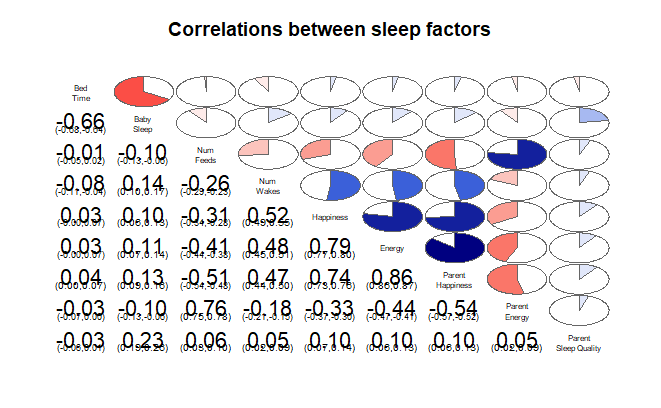

```r
## let's start with a quick look at all the correlations at the diary level
cols<-c('relativebedtime','hourssleep',
        'numwakes','happiness',
        'parent.happiness','parent.energy',
        'parent.sleepquality','parent.totalwakes',
        'parent.hourssleep')
lbls<-c('Bed\nTime','Baby\nSleep','Num\nFeeds',
        'Num\nWakes','Happiness','Energy',
        'Parent\nHappiness','Parent\nEnergy',
        'Parent\nSleep Quality','Parent\nWakes','Parents\nSleep Efficiency',
        'Parent\nSleep Hours','Parent\nSleep Time')


corrgram(diaries[,cols],order=FALSE, lower.panel=panel.conf,
         upper.panel=panel.pie, text.panel=panel.txt,
         diag.panel= NULL,labels = lbls,
         main="Correlations between sleep factors")
```

```r
NA
NA
```

```r
apa.cor.table(diaries[,cols],filename = "Parent sleep corrs.doc")
```

```
Means, standard deviations, and correlations with confidence intervals


  Variable               M     SD   1            2            3            4            5            6
  1. relativebedtime     7.75  0.99

  2. hourssleep          11.00 1.11 -.66**
                                    [-.68, -.64]

  3. numwakes            1.29  1.59 -.01         -.10**
                                    [-.05, .02]  [-.13, -.06]

  4. happiness           7.75  1.81 -.08**       .14**        -.26**
                                    [-.11, -.04] [.10, .17]   [-.29, -.23]

  5. parent.happiness    7.20  1.97 .03          .10**        -.31**       .52**
                                    [-.00, .07]  [.06, .13]   [-.34, -.28] [.49, .55]

  6. parent.energy       6.51  2.22 .03          .11**        -.41**       .48**        .79**
                                    [-.00, .07]  [.07, .14]   [-.44, -.38] [.45, .51]   [.77, .80]

  7. parent.sleepquality 6.57  2.22 .04*         .13**        -.51**       .47**        .74**        .86**
                                    [.00, .07]   [.09, .16]   [-.54, -.48] [.44, .50]   [.73, .76]   [.86, .87]

  8. parent.totalwakes   2.15  2.61 -.03         -.10**       .76**        -.18**       -.33**       -.44**
                                    [-.07, .00]  [-.13, -.06] [.75, .78]   [-.21, -.15] [-.37, -.30] [-.47, -.41]

  9. parent.hourssleep   7.94  1.50 -.03         .23**        .06**        .05**        .10**        .10**
                                    [-.06, .01]  [.19, .26]   [.03, .10]   [.02, .09]   [.07, .14]   [.06, .13]

  7            8









```

[output cut: 8 more lines]

```



  -.54**
  [-.57, -.52]

  .10**        .05**
  [.06, .13]   [.02, .09]


Note. M and SD are used to represent mean and standard deviation, respectively.
Values in square brackets indicate the 95% confidence interval.
The confidence interval is a plausible range of population correlations
that could have caused the sample correlation (Cumming, 2014).
 * indicates p < .05. ** indicates p < .01.
```

```r
cor.test(diaries$parent.sleepquality, diaries$parent.totalwakes)
```

```
    Pearson's product-moment correlation

data:  diaries$parent.sleepquality and diaries$parent.totalwakes
t = -36, df = 3060, p-value <2e-16
alternative hypothesis: true correlation is not equal to 0
95 percent confidence interval:
 -0.566 -0.516
sample estimates:
   cor
-0.541
```

```r
corr.p<-function(x, y){
  #run correlation of x & y and return p-value
  cr <- cor.test(x,y)
  return (cr$p.value)
}
```

```r
for (i in 1:length(cols)){
  for (j in 1:length(cols)){
      if(j<i){
    #    print(paste(i,j))
        cr <- corr.p(diaries[,cols[i]],diaries[,cols[j]])
        print(paste(cols[i],cols[j],cr))
      }
  }

}
```

```
[1] "hourssleep relativebedtime 0"
[1] "numwakes relativebedtime 0.539680084375445"
[1] "numwakes hourssleep 4.05979300548151e-08"
[1] "happiness relativebedtime 1.41444574022664e-05"
[1] "happiness hourssleep 1.02234727064457e-14"
[1] "happiness numwakes 2.20537508918702e-48"
[1] "parent.happiness relativebedtime 0.0845058938006482"
[1] "parent.happiness hourssleep 5.05620969583775e-08"
[1] "parent.happiness numwakes 5.44847539198441e-70"
[1] "parent.happiness happiness 9.50203092388641e-212"
[1] "parent.energy relativebedtime 0.0705005405832837"
[1] "parent.energy hourssleep 1.76153686455321e-09"
[1] "parent.energy numwakes 2.11901300313123e-125"
[1] "parent.energy happiness 1.8897353693316e-175"
[1] "parent.energy parent.happiness 0"
```

[output cut: 21 more lines]

## Exploratory Analysis

(Not in the submitted paper. )

```r
hist(babies$DaysOld)
hist(diaries$happiness)
hist(as.numeric(na.omit(diaries$hourssleep)))
hist(as.numeric(na.omit(diaries$relativebedtime)))
hist(as.numeric(na.omit(diaries$parenthourssleep)))









##higher level correlations
cols<-c('DaysOld','hourssleep','relativebedtime',
        'sleepvariations',
        'SURGENCY','NEG_AFFECT','EFFORTFUL',
        'energy','happiness',
        'parentenergy','parenthappiness','parenthourssleep','parentsleepvariations')
lbls<-c('Baby\nAge','Baby\nSleep','Bed\nTime','Sleep\nVariations',
        'Surgency','Negative\nAffect','Effortful',
        'Energy','Happiness','Parent\nEnergy','Parent\nHappiness',
        'Parent\nHours Sleep', 'Parent\nVariations')

corrgram(babies[,cols],order=FALSE, lower.panel=panel.conf,
         upper.panel=panel.pie, text.panel=panel.txt,
         diag.panel= NULL,labels = lbls,
         main="Grand average correlations")


#break down of averages per condition
aggregate(hourssleep ~ product * week, diaries,mean)
aggregate(happiness ~ product * week, diaries,mean)
aggregate(energy ~ product * week, diaries,mean)

aggregate(hourssleep ~ week, diaries,mean)
aggregate(happiness ~ week,  diaries,mean)
aggregate(energy ~ week,     diaries,mean)

aggregate(hourssleep ~ product, diaries,mean)
aggregate(happiness ~ product,  diaries,mean)
aggregate(energy ~ product,     diaries,mean)

#aggregate(sleepvariations ~ product,     diaries,mean)


##are these significant?
h1 <- diaries %>% filter(!is.na(hourssleep))  %>% group_by(Resp_id,week) %>% select(Resp_id,week,product,hourssleep)  %>% summarise(product=first(product),avsleep=mean(hourssleep))
h1 <-data.frame(h1)
ezANOVA(h1,dv=avsleep,wid=.(Resp_id),within = .(product))

h1 <- diaries %>% filter(!is.na(happiness))  %>% group_by(Resp_id,week) %>% select(Resp_id,product,happiness)  %>% summarise(product=first(product),avhappiness=mean(happiness))
h1 <-data.frame(h1)
ezANOVA(h1,dv=avhappiness,wid=.(Resp_id),within = .(product))

h1 <- diaries %>% filter(!is.na(energy))  %>% group_by(Resp_id,week) %>% select(Resp_id,product,energy)  %>% summarise(product=first(product),avenergy=mean(energy))
h1 <-data.frame(h1)
ezANOVA(h1,dv=avenergy,wid=.(Resp_id),within = .(product))


table(diaries$diary.Q10_1, diaries$product )
table(diaries$diary.Q10_2, diaries$product )
table(diaries$diary.Q10_3, diaries$product )
table(diaries$diary.Q10_4, diaries$product )


sleeplm<-lm(hourssleep ~ product + (1/Resp_id),data=diaries)
summary.lm(sleeplm)

happylm<-lm(happiness ~ product + (1/Resp_id),data=diaries)
summary.lm(happylm)

energylm<-lm(energy ~ product + (1/Resp_id),data=diaries)
summary.lm(energylm)




##################
## GRAPHS
##################
theme_set(theme_few(base_size = 18))

ggplot(diaries, aes(product,energy )) + stat_boxplot()

ggplot(diaries,aes(hourssleep,happiness)) +
  aes(color=as.factor(product)) +
  geom_smooth(method=lm,size=1.5) +
  facet_grid(.~product) +
  xlab("Hours of sleep") + ylab("Happiness score") +
  theme(legend.position = "none")

ggplot(diaries,aes(hourssleep,energy)) +
  aes(color=as.factor(product)) +
  geom_smooth(method=lm,size=1.5) +
  facet_grid(.~product) +
  xlab("Hours of sleep") + ylab("Energy score") +
  theme(legend.position = "none")


bed.lm <-lm(hourssleep ~ 1 + relativebedtime+ (1/Resp_id),
            data = diaries)
summary(bed.lm)


glmulti.lm.out <-
  glmulti(hourssleep ~ DaysOld  +relativebedtime + product + numwakes +  feed  + changed + (1/Resp_id),
          data = diaries,
          level = 1,               # No interaction considered
          method ="g",             # "h" = Exhaustive approach, "l" = fast branch bound
          crit = "aic",            # AIC as criteria
          confsetsize = 5,         # Keep 5 best models
          plotty = F, report = F,  # No plot or interim reports
          fitfunction = "lm")      # lm function

## Show 5 best models (Use @ instead of $ for an S4 object)
glmulti.lm.out@formulas
summary(glmulti.lm.out@objects[[1]])


glmulti.lm.out <-
  glmulti(happiness ~ DaysOld  +relativebedtime + product + numwakes +  feed  + changed + (1/Resp_id),
          data = diaries,
          level = 2,               # No interaction considered
          method ="g",             # "h" = Exhaustive approach, "l" = fast branch bound
          crit = "aic",            # AIC as criteria
          confsetsize = 5,         # Keep 5 best models
          plotty = F, report = F,  # No plot or interim reports
          fitfunction = "lm")      # lm function

## Show 5 best models (Use @ instead of $ for an S4 object)
glmulti.lm.out@formulas
summary(glmulti.lm.out@objects[[1]])


glhappiness <-
  glmulti(happiness ~ DaysOld  + hourssleep + product + numwakes +  feed + diaperstate + changed + (1/Resp_id),
          data = diaries,
          level = 1,               # No interaction considered
          method = "1",            # Exhaustive approach
          crit = "aic",            # AIC as criteria
          confsetsize = 5,         # Keep 5 best models
          plotty = F, report = F,  # No plot or interim reports
          fitfunction = "lm")      # lm function

## Show 5 best models (Use @ instead of $ for an S4 object)
glhappiness@formulas
summary(glhappiness@objects[[1]])

glenergy <-
  glmulti(energy ~ DaysOld  + hourssleep + product + numwakes +  feed + diaperstate + changed + (1/Resp_id),
          data = diaries,
          level = 1,               # No interaction considered
          method = "1",            # Exhaustive approach
          crit = "aic",            # AIC as criteria
          confsetsize = 5,         # Keep 5 best models
          plotty = F, report = F,  # No plot or interim reports
          fitfunction = "lm")      # lm function

## Show 5 best models (Use @ instead of $ for an S4 object)
glenergy@formulas
summary(glenergy@objects[[1]])


ggplot(diaries,aes(energy~diaperstate)) +
  aes(color=as.factor(diaperstate)) +
  facet_grid(.~product) +
  xlab("Hours of sleep") + ylab("Energy score") +
  theme(legend.position = "none")

aggregate(happiness ~ diaperstate , diaries,mean)


###########################################
## BRASIL STYLE DIAGRAMS
###########################################

g1<-ggplot(diaries,aes(hourssleep))
(g1+geom_density()
+ aes(fill=as.factor(product))
+ geom_density(alpha=.3)
+ xlim(c(4,14))
+ xlab("Hours sleep per night")
+ ggtitle("Average hours sleep")
+ facet_grid(product~.)
+ theme(legend.position = "none",
        strip.text.y=element_text(size = 24),
        axis.title.y=element_blank(),
        axis.ticks = element_blank(),
        axis.text.y = element_blank(),
        axis.text=element_text(size=24),
        axis.title=element_text(size=18))
)

(ggplot(diaries,aes(happiness))
+ geom_histogram(stat="count", bins )
+ ggtitle("Happiness")
+ aes(fill=as.factor(product))
+ geom_density(alpha=.3)
+ xlim(c(1,10))
+ xlab("Happiness")
+ facet_grid(product~.)
+ theme(legend.position = "none",
        strip.text.y=element_text(size = 24),
        axis.title.y=element_blank(),
        axis.ticks = element_blank(),
        axis.text.y = element_blank(),
        axis.text=element_text(size=24),
        axis.title=element_text(size=18)))



(ggplot(diaries,aes(energy))
+ geom_density()
+ ggtitle("Energy")
+ aes(fill=as.factor(product))
+ geom_density(alpha=.3)
+ xlim(c(1,10))
+ xlab("Energy")
+ facet_grid(product~.)
+ theme(legend.position = "none",
        strip.text.y=element_text(size = 24),
        axis.title.y=element_blank(),
        axis.ticks = element_blank(),
        axis.text.y = element_blank(),
        axis.text=element_text(size=24),
        axis.title=element_text(size=18))
)



ggplot(diaries,aes(relativebedtime,hourssleep)) +
  geom_jitter() +
  geom_smooth(method=lm) +
  scale_x_continuous(breaks = c(6,8,10,12), labels=c("6" = "6 PM", "8" = "8 PM","10"= "10 PM","12" = "12 AM")) +
  ylab("Hours of sleep") + xlab("Bedtime") +
  theme(legend.position = "none")
cor.test(diaries$hourssleep,diaries$relativebedtime,use = "pairwise.complete.obs")



ggplot(diaries,aes(hourssleep,parenthourssleep)) +
  geom_jitter() +
  geom_smooth(method=lm) +
  ylab("Parent hours of sleep") + xlab("Baby hours of sleep") +
  theme(legend.position = "none")
cor.test(diaries$hourssleep,diaries$parenthourssleep,use = "pairwise.complete.obs")


ggplot(diaries,aes(numwakes,parentsleepquality)) +
  geom_jitter() +
  geom_smooth(method=lm) +
  ylab("Parent Sleep Quality") + xlab("Baby wakes per night") +
  theme(legend.position = "none")
cor.test(diaries$numwakes,diaries$parentsleepquality,use = "pairwise.complete.obs")



h2 <- diaries %>% filter(!is.na(diary.Q9) & diary.Q9>0)
(ggplot(diaries,aes(x=happiness))+stat_bin(binwidth = 1,origin=0)
 + facet_grid(diary.Q9~.)
 + ggtitle("Happiness vs wetness"))

(ggplot(diaries,aes(x=energy))+stat_bin(binwidth = 1,origin=0)
+ facet_grid(diary.Q9~.)
+ ggtitle("Energy vs wetness"))

theme_set(theme_few(base_size = 18))
### 1 ###
#how happy was your baby
diaries$over8<-ifelse(diaries$happiness>7,"blue","skyblue")
table(diaries$over8)
ggplot(diaries,aes(happiness, fill = over8)) +
  scale_x_discrete(limits=1:10) +
  geom_bar(binwidth=1,origin=0.5) +
  xlab("Happiness") +
  ggtitle("On a scale of 1 to 10 how happy\n was your baby this morning?") +
  annotate("text",x=9,y=140,label="64%",size =18) +
  theme(legend.position = "none",
        strip.text.y=element_text(size = 24),
        axis.title.y=element_blank(),
        axis.ticks = element_blank(),
        axis.text.y = element_blank(),
        axis.text=element_text(size=18),
        axis.title=element_text(size=18))

#how energetic.
diaries$over82<-ifelse(diaries$energy>7,"blue","skyblue")
t(table(diaries$over82))
t(table(diaries$energy))
write.csv(table(diaries$energy),"energy.csv")
ggplot(diaries,aes(energy, fill = over82)) +
  scale_x_discrete(limits=1:10) +
  geom_bar(binwidth=1,origin=0.5) +
  xlab("Energy") +
  ggtitle("On a scale of 1 to 10 how energetic\n was your baby this morning?") +
  annotate("text",x=9,y=95,label="57%",size =18) +
  theme(legend.position = "none",
        strip.text.y=element_text(size = 24),
        axis.title.y=element_blank(),
        axis.ticks = element_blank(),
        axis.text.y = element_blank(),
        axis.text=element_text(size=18),
        axis.title=element_text(size=18))
```